# Projet : Modèles de prévisions

Ali ELbouhi - Omar Oumlala - Mourad Ait Si Hammou

04/11/2022

Import library

```r
knitr::opts_chunk$set(fig.width=12, fig.height=8)
setwd(getwd())
library(tseries)
library(lmtest)
library(forecast)
library(ggplot2)
```

Import data : reference (https://fred.stlouisfed.org/series/GDP)

```r
df <- read.csv('GDP_USA.csv',sep=',')
```

Convert US gdp data into time series

```r
gdp  <- ts(df$GDP,start=c(1947,1,1),frequency = 4)
gdp_ts <- window(gdp,start=c(1950,1),end=c(2021,4))
gdp_ts_test <- window(gdp,start=c(2022,1))
```

Extract seasonality and trend from our ts

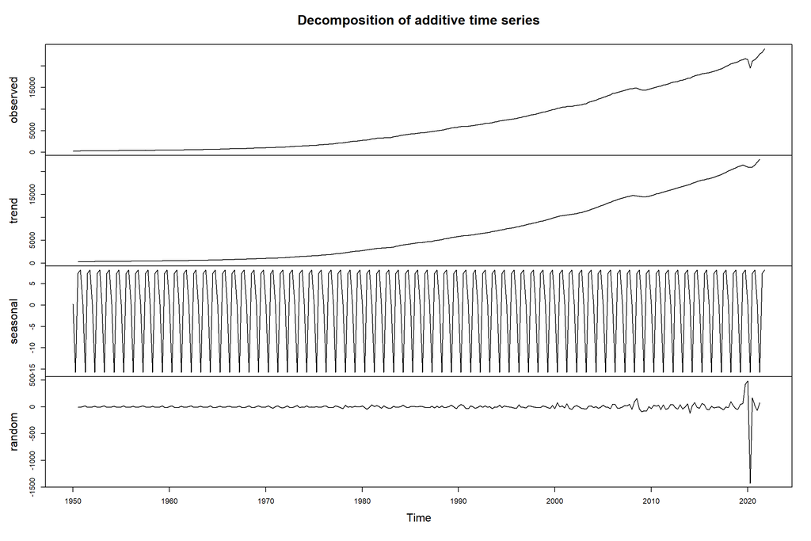

```r
gdp_ts_component <- decompose(gdp_ts)
plot(gdp_ts_component)
```

As shown in the figure above, both variables are approximately follow exponential form with a general increasingtrend. In other words the original GDP sequence are non-stationary. However, In order to confirm this conclusion, we plotted the Autocorrelation Function (ACF) and the Partial Autocorrelation Function (PACF) against lags which are known as (Correlogram) to both series,

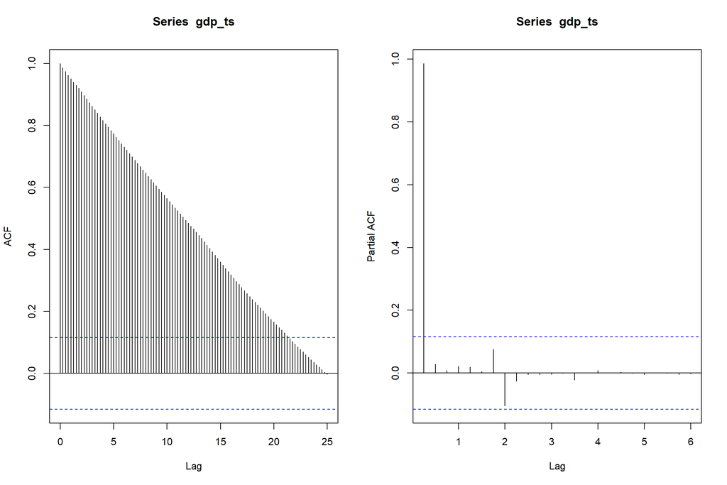

```r
par(mfrow=c(1,2))
acf_gdp<- acf(gdp_ts,lag.max=100)
pacf_gdp <- pacf(gdp_ts)
```

```r
Box.test(gdp_ts, lag=20, type="Ljung-Box")
```

```
##
##  Box-Ljung test
##
## data:  gdp_ts
## X-squared = 4665.5, df = 20, p-value < 2.2e-16
```

The figure clearly shows that the most striking feature of this correlogram is that the autocorrelation coefficients at various lags are high even up to a lag of 20 for GDP,In addition, the Q-statistic of Ljung-Box (1978) at the 20th lag has a probability value of 0.000, so we can conclude that GDP is non-stationary.

Thus, the series must be transformed to be stationary. To eliminate non-stationarity, we took the natural logarithm of GDP thus obtaining a new variables named lgdp

```r
lgdp=log(gdp_ts)
adf.test(lgdp)
```

```
##
##  Augmented Dickey-Fuller Test
##
## data:  lgdp
## Dickey-Fuller = 0.34807, Lag order = 6, p-value = 0.99
## alternative hypothesis: stationary
```

After applying the Augmented Dickey-Fuller (ADF) test to the series, the results showed that LGDP were still non-stationary

Therefore, the first-order difference was taken, for the serie producing a new variables DLGDP. These variable proved not to be stationary as confirmed by the result of the acf and pacf correlation;

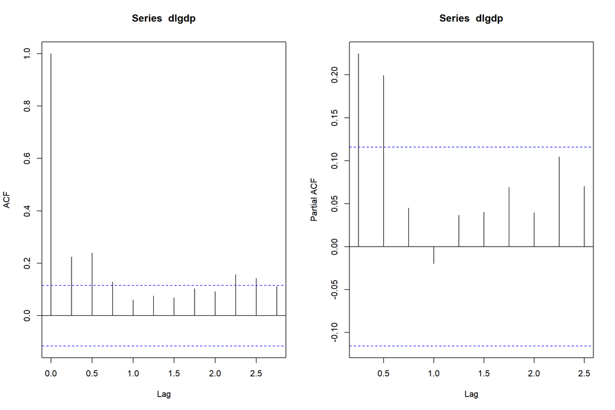

```r
dlgdp <- diff(lgdp)
par(mfrow=c(1,2))
acf(dlgdp,lag.max=11)
pacf(dlgdp,lag.max=10)
```

Therefore, the second-order difference was taken, for the serie producing a new variables DDLGDP. These variable proved to be stationary as confirmed by the results of the ADF test.

```r
ddlgdp <- diff(dlgdp)
adf.test(ddlgdp)
```

```
##
##  Augmented Dickey-Fuller Test
##
## data:  ddlgdp
## Dickey-Fuller = -9.7442, Lag order = 6, p-value = 0.01
## alternative hypothesis: stationary
```

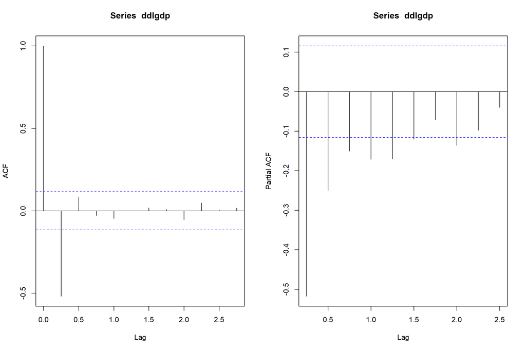

```r
par(mfrow=c(1,2))
acf(ddlgdp,lag.max=11)
pacf(ddlgdp,lag.max=10)
```

In order to forecast GDP, that combination can be made automatically, and an optimal one can be chosen based on minimum AIC

```r
model1 <- arima(lgdp,order=c(0,2,3))
AIC(model1)
```

```
## [1] -1693.827
```

```r
model2 <- arima(lgdp,order=c(1,2,8))
AIC(model2)
```

```
## [1] -1683.72
```

```r
model3 <- arima(lgdp,order = c(3,2,3))
AIC(model3)
```

```
## [1] -1688.224
```

Results indicated that the ARIMA (0, 2, 3) is the best fit more over the auto.arima function confirm our pre-selected parameters.

```r
ar_model <- auto.arima(lgdp,stepwise = FALSE,approximation = FALSE)
ar_model
```

```
## Series: lgdp
## ARIMA(0,2,3)
##
## Coefficients:
##           ma1     ma2      ma3
##       -0.8534  0.0648  -0.1487
## s.e.   0.0585  0.0823   0.0611
##
## sigma^2 = 0.0001533:  log likelihood = 850.91
## AIC=-1693.83   AICc=-1693.68   BIC=-1679.2
```

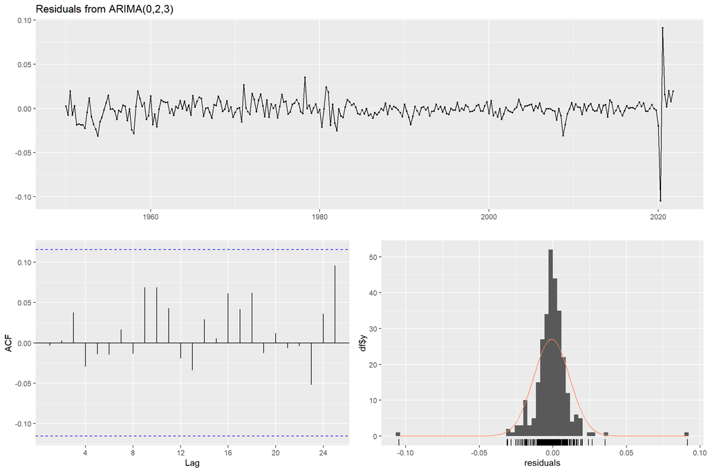

```
##
##  Ljung-Box test
##
## data:  Residuals from ARIMA(0,2,3)
## Q* = 0.93381, df = 5, p-value = 0.9677
##
## Model df: 3.   Total lags used: 8
```

```r
residual_plot<- checkresiduals(model1)
```

```r
residual_plot
```

```
##
##  Ljung-Box test
##
## data:  Residuals from ARIMA(0,2,3)
## Q* = 0.93381, df = 5, p-value = 0.9677
```

The ACF plot of the residuals from the ARIMA(0,2,3) model shows that all autocorrelations are within the threshold limits, indicating that the residuals are behaving like white noise. A portmanteau test returns a large p-value, also suggesting that the residuals are white noise.

One of the chosen fitted models which are summarized in the Figure above is ARIMA (0,2,3). It can be applied to DDLGDP in order to forecast the values of LGDP. It have been estimated with the results as : $DDLGDP= -0.8534\epsilon_{t-1} + 0.0648\epsilon_{t-2} -0.1487\epsilon_{t-3}$

We will compare our forecasted value between the test set which is the 2022Q1 & 2022Q2. Bellow we can see our forecasted points and our interval confidance :

```r
l_forecasted = forecast(model1,h=2)
summary(l_forecasted)
```

```
##
## Forecast method: ARIMA(0,2,3)
##
## Model Information:
##
## Call:
## arima(x = lgdp, order = c(0, 2, 3))
##
## Coefficients:
##           ma1     ma2      ma3
##       -0.8534  0.0648  -0.1487
## s.e.   0.0585  0.0823   0.0611
##
## sigma^2 estimated as 0.0001515:  log likelihood = 850.91,  aic = -1693.83
##
## Error measures:
##                         ME       RMSE         MAE         MPE       MAPE
## Training set -0.0009317779 0.01227294 0.007225039 -0.01366347 0.09448783
##                   MASE         ACF1
## Training set 0.1150928 -0.003336781
##
## Forecasts:
##         Point Forecast    Lo 80    Hi 80    Lo 95    Hi 95
## 2022 Q1       10.10066 10.08489 10.11644 10.07654 10.12478
## 2022 Q2       10.11549 10.09150 10.13949 10.07879 10.15219
```

```r
acc_l_forecasted <- accuracy(object = l_forecasted,x = log(gdp_ts_test))
acc_l_forecasted
```

```
##                         ME       RMSE         MAE         MPE       MAPE
## Training set -0.0009317779 0.01227294 0.007225039 -0.01366347 0.09448783
## Test set      0.0037862685 0.00462470 0.003786269  0.03741770 0.03741770
##                    MASE         ACF1 Theil's U
## Training set 0.11509283 -0.003336781        NA
## Test set     0.06031418 -0.500000000 0.3198425
```

As we see our metric error are low when we compare against our forecasted values between the test set. MAPE metric is commonly used because it’s easy to interpret and explain. Our MAPE value of 0.037% means that the average difference between the forecasted value and the actual value is 0.037%. Which is very low , we can affirm that our model is highly precise concerning the LGDP.

For better visibility I will plot our time series starting 2019.

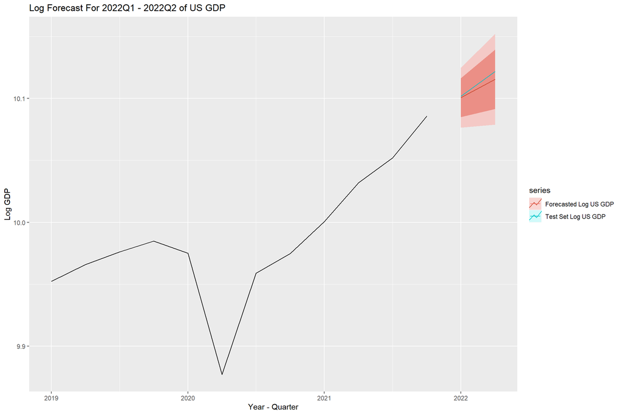

```r
sub_ts <- window(lgdp,start=c(2019))
autoplot(sub_ts,main = 'Log Forecast For 2022Q1 - 2022Q2 of US GDP',xlab = 'Year - Quarter',ylab = 'Log GDP')+
  autolayer(l_forecasted, "Forecasted Log US GDP")+
  autolayer(log(gdp_ts_test),series = 'Test Set Log US GDP')
```

Now lets predict the GDP by applying the exponential to our series.

```r
forecasted = l_forecasted
forecasted$mean=exp(l_forecasted$mean)
forecasted$lower=exp(l_forecasted$lower)
forecasted$upper=exp(l_forecasted$upper)
summary(forecasted)
```

```
##
## Forecast method: ARIMA(0,2,3)
##
## Model Information:
##
## Call:
## arima(x = lgdp, order = c(0, 2, 3))
##
## Coefficients:
##           ma1     ma2      ma3
##       -0.8534  0.0648  -0.1487
## s.e.   0.0585  0.0823   0.0611
##
## sigma^2 estimated as 0.0001515:  log likelihood = 850.91,  aic = -1693.83
##
## Error measures:
##                         ME       RMSE         MAE         MPE       MAPE
## Training set -0.0009317779 0.01227294 0.007225039 -0.01366347 0.09448783
##                   MASE         ACF1
## Training set 0.1150928 -0.003336781
##
## Forecasts:
##         Point Forecast    Lo 80    Hi 80    Lo 95    Hi 95
## 2022 Q1       24359.18 23978.00 24746.41 23778.64 24953.89
## 2022 Q2       24723.10 24136.91 25323.53 23832.24 25647.26
```

```r
acc_forecasted <- accuracy(object = forecasted,x = gdp_ts_test)
acc_forecasted
```

```
##                         ME         RMSE          MAE         MPE       MAPE
## Training set -0.0009317779   0.01227294  0.007225039 -0.01366347 0.09448783
## Test set     93.6673810402 114.64706304 93.667381040  0.37755970 0.37755970
##                      MASE         ACF1 Theil's U
## Training set    0.1150928 -0.003336781        NA
## Test set     1492.0947725 -0.500000000 0.3220359
```

Our MAPE value of 0,378% means that the average difference between the forecasted value and the actual value is 0,378%. Which is very low , we can affirm that our model is highly precise concerning the GDP.

For better visibility I will plot our time series starting 2019.

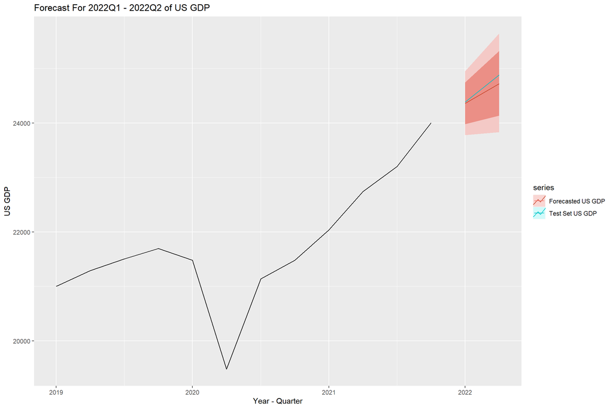

```r
sub_ts <- window(gdp_ts,start=c(2019))
autoplot(sub_ts,main = 'Forecast For 2022Q1 - 2022Q2 of US GDP',xlab = 'Year - Quarter',ylab = 'US GDP')+
  autolayer(forecasted, "Forecasted US GDP")+
  autolayer(gdp_ts_test,series = 'Test Set US GDP')
```